# Lab 4: Data Visualization

Author

Maxim Dokukin

Published

February 20, 2024

Remember, **follow the instructions below and use R Markdown to create a pdf document with your code and answers to the following questions on Gradescope.** You may find a template file by clicking ‘Code’ in the top right corner of this page.

### Collaborators

INSERT NAMES OF ANY COLLABORATORS

```r
library(tidyverse)
library(ggplot2)
```

## A. Basic visualizations

For this portion, we’ll be using the `palmerpenguins` data. Use the following code to load the data.

```r
library(palmerpenguins)
data(penguins)
```

1. Create and interpret a histogram of `bill_length_mm` using base R code. Be sure to use meaningful axis labels and titles.

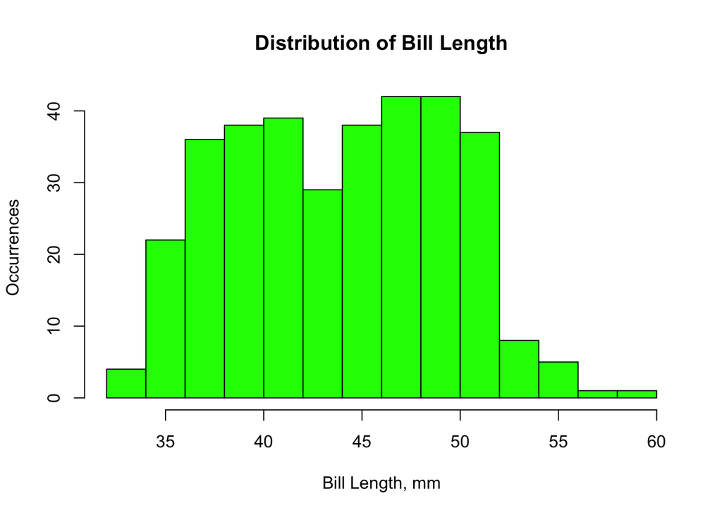

```r
hist(
  penguins$bill_length_mm,
  main = 'Distribution of Bill Length',
  xlab = 'Bill Length, mm',
  ylab = 'Occurrences',
  col = 'green'
)
```

47-50mm is the most common occurrence of Bill Length.

2. Create and interpret a histogram of `bill_length_mm` using ggplot2. Be sure to use meaningful axis labels and titles.

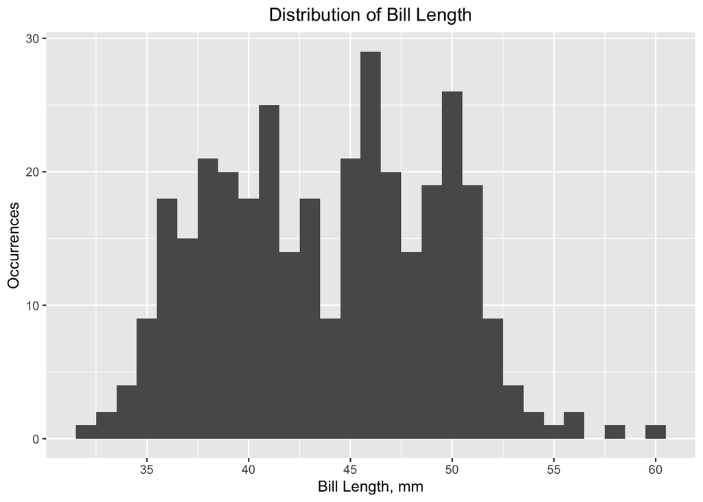

```r
ggplot(data = penguins,
       aes(x = bill_length_mm)) +
  geom_histogram(binwidth=1) +
  xlab('Bill Length, mm') +
  ylab('Occurrences') +
  ggtitle('Distribution of Bill Length') +
  theme(plot.title = element_text(hjust = 0.5))+
  scale_x_continuous(breaks = seq(30, 60, by = 5))
```

Looks like bimodal distribution. 45-47mm is the most common occurence of Bill Length.

3. Create and interpret a scatterplot of `bill_length_mm` versus `bill_depth_mm` using base R code. Be sure to use meaningful axis labels and titles.

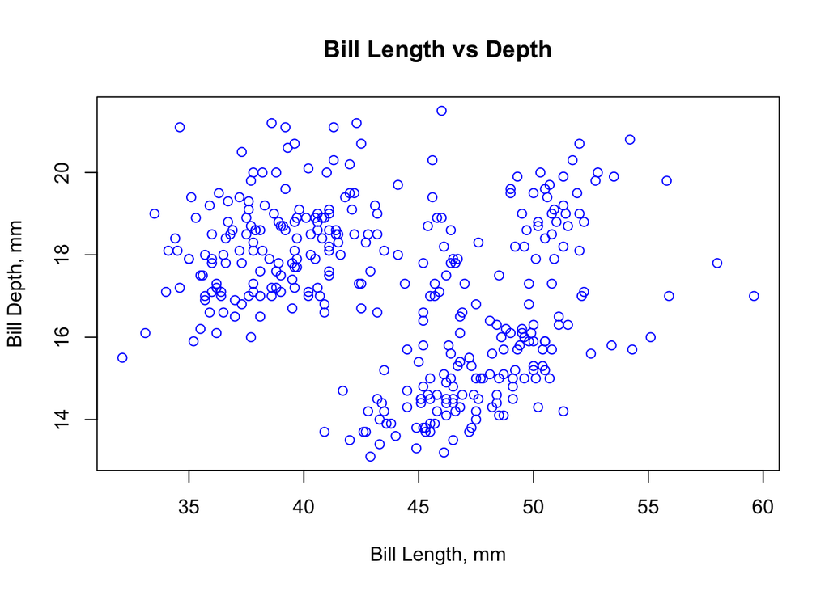

```r
plot(
  x = penguins$bill_length_mm,
  y = penguins$bill_depth_mm,
  main = 'Bill Length vs Depth',
  xlab = 'Bill Length, mm',
  ylab = 'Bill Depth, mm',
  col = 'blue',
)
```

Data seems to be forming 3 clusters.

4. Create and interpret a scatterplot of `bill_length_mm` versus `bill_depth_mm` using ggplot2. Be sure to use meaningful axis labels and titles.

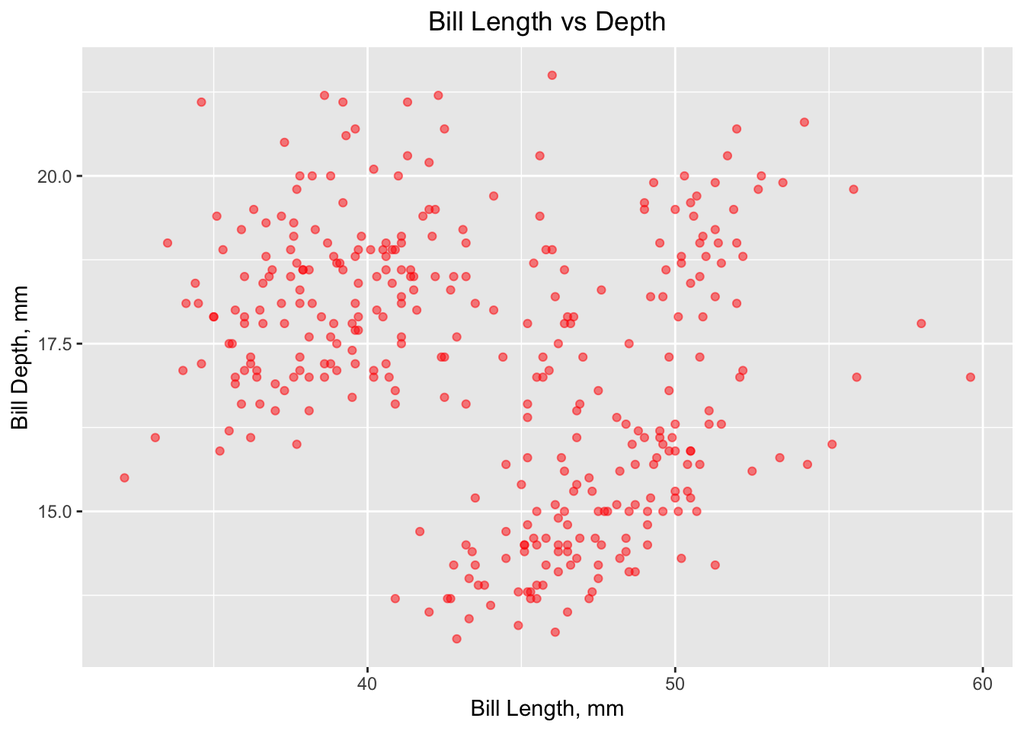

```r
ggplot(data = penguins,
       aes(x = bill_length_mm, y = bill_depth_mm)) +
  geom_point(color = 'red', alpha = 0.5)  +
  xlab('Bill Length, mm') +
  ylab('Bill Depth, mm') +
  ggtitle('Bill Length vs Depth')+
  theme(plot.title = element_text(hjust = 0.5))
```

Data seems to be forming 3 clusters.

5. Update your `ggplot2` scatterplot of `bill_length_mm` versus `bill_depth_mm` using ggplot2 so that the color of a point represents the corresponding penguin’s species. What do you notice?

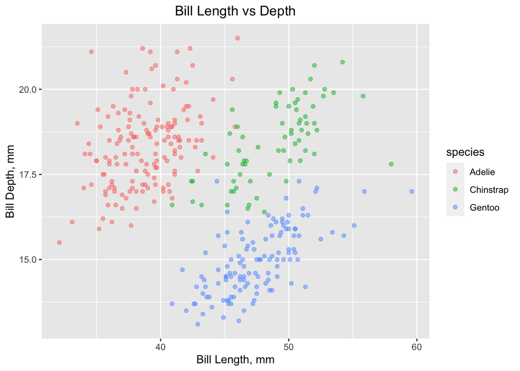

```r
ggplot(data = penguins,
       aes(x = bill_length_mm, y = bill_depth_mm, color=species)) +
  geom_point(alpha = 0.5)  +
  xlab('Bill Length, mm') +
  ylab('Bill Depth, mm') +
  ggtitle('Bill Length vs Depth')+
  theme(plot.title = element_text(hjust = 0.5))
```

Data indeed forms 3 clusters, characterized by species.

## B. Analyzing trends in San Jose rental prices

For this component, you will be exploring and visualizing data on Craigslist apartment rental postings in the Bay Area. The data are available [here](https://raw.githubusercontent.com/rfordatascience/tidytuesday/master/data/2022/2022-07-05/rent.csv) from Tidy Tuesday, as prepared by [Dr. Kate Pennington](https://github.com/rfordatascience/tidytuesday/blob/master/data/2022/2022-07-05/readme.md). Note that you can use links within `read_csv()` to read online .csv files. I recommend saving a version of the unprocessed .csv on your machine in a `data` subfolder within your project folder so you will be able to work offline.

```r
rent <- readr::read_csv('https://raw.githubusercontent.com/rfordatascience/tidytuesday/master/data/2022/2022-07-05/rent.csv')
summary(rent)
```

```r
head(rent)
```

6. How many 1 bedroom listings from Santa Clara county are in this dataset?

```r
sc_onebed <- rent |> filter(beds == 1, county == 'santa clara')
print(paste(nrow(sc_onebed), 'one bedroom listings in Santa Clara county'))
```

```
[1] "12455 one bedroom listings in Santa Clara county"
```

7. What is the median price for a 1 bedroom listing in Santa Clara county in 2018?

```r
sc_onebed_2018 <- rent |> filter(beds == 1, county == 'santa clara', year == 2018)
print(paste('Median price for a 1 bedroom listing in Santa Clara county in 2018 is $',
            median(sc_onebed_2018$price)))
```

```
[1] "Median price for a 1 bedroom listing in Santa Clara county in 2018 is $ 2095"
```

8. Which county has the highest median price for a 1 bedroom listing in 2018?

```r
county_medians <- rent |> filter(beds == 1, year == 2018) |>
                          group_by(county) |>
                          summarize(median_price = median(price))

most_expesive_county <- county_medians[which.max(county_medians$median_price), ]

print(paste('Most expensive county:', most_expesive_county[, 'county']))
```

```
[1] "Most expensive county: san francisco"
```

```r
print(paste('With median price for a 1 bedroom in 2018: $',
            most_expesive_county[, 'median_price']))
```

```
[1] "With median price for a 1 bedroom in 2018: $ 3000"
```

9. Create two histograms for the prices of 1 bedroom listings in Santa Clara county in 2005 and 2018. Compare and discuss.

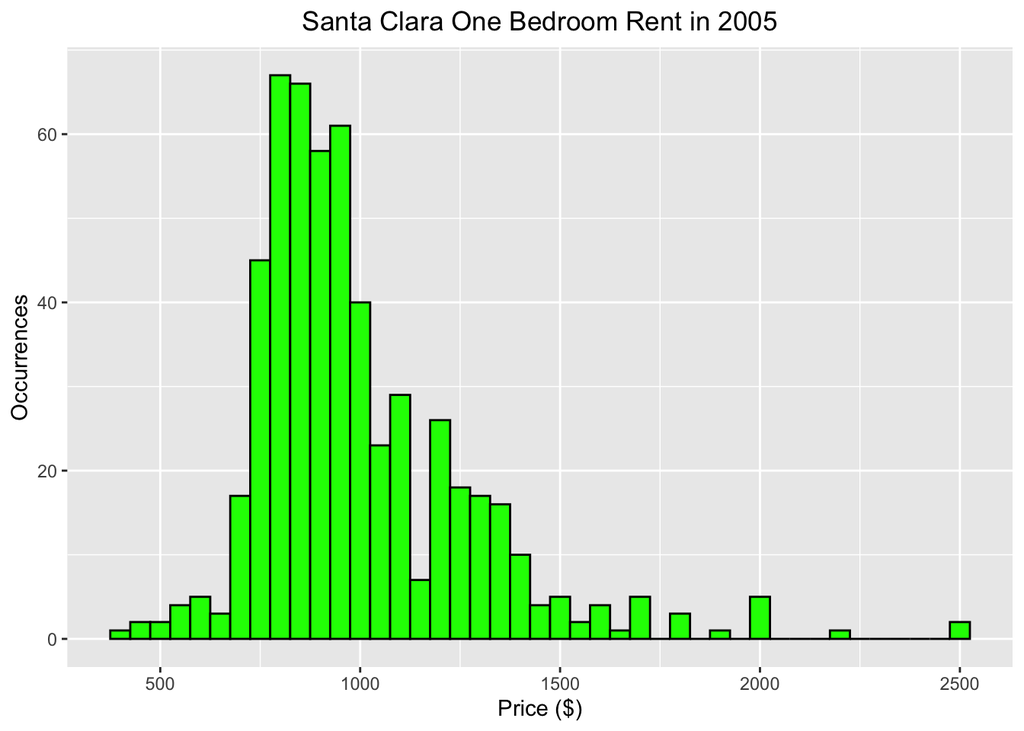

```r
sc_onebed_2005 <- rent |> filter(county == 'santa clara', beds == 1, year == 2005)
sc_onebed_2018 <- rent |> filter(county == 'santa clara', beds == 1, year == 2018)


ggplot(data = sc_onebed_2005,
       aes(x = price)) +
       geom_histogram(binwidth=50, fill='green', color = 'black') +
       xlab('Price ($)') +
       ylab('Occurrences') +
       ggtitle('Santa Clara One Bedroom Rent in 2005') +
       theme(plot.title = element_text(hjust = 0.5))
```

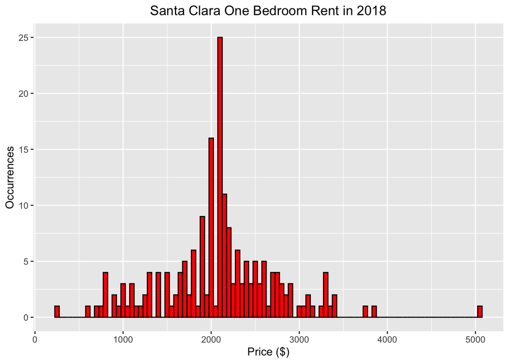

```r
ggplot(data = sc_onebed_2018,
       aes(x = price)) +
       geom_histogram(binwidth=50, fill='red', color = 'black') +
       xlab('Price ($)') +
       ylab('Occurrences') +
       ggtitle('Santa Clara One Bedroom Rent in 2018') +
       theme(plot.title = element_text(hjust = 0.5))
```

10. Create and interpret a line plot with year on the x-axis and median price for a 1 bedroom apartment for Santa Clara county on the y-axis from 2000 to 2018.

[figure not shown]

```r
sc_median_byyears <- rent |> filter(county == 'santa clara',
                                    year >= 2000,
                                    year <= 2018) |>
                             group_by(year) |>
                             summarize(median_price = median(price))
ggplot(sc_median_byyears,
       aes(x = year, y = median_price)) +
       geom_line() +
       labs(title = 'Median Price for a 1 bedroom apartment for Santa Clara',
            x = 'Year',
            y = 'Price ($)') +
       theme(plot.title = element_text(hjust = 0.5))
```

Average prices dipped in 2001-2005, but luckly grew significantly for the following years.

11. Create and interpret a single plot with year on the x-axis and median price for a 1 bedroom apartment on the y-axis, using a separate line for each city in Santa Clara county, for the years 2000 to 2018.

[figure not shown]

```r
sc_median_byyears <- rent |> filter(county == 'santa clara',
                                    year >= 2000,
                                    year <= 2018) |>
                             group_by(city, year) |>
                             summarize(median_price = median(price))

ggplot(sc_median_byyears,
       aes(x = year, y = median_price, color = city)) +
       geom_line() +
       labs(title = 'Median Price for a 1 bedroom apartment in Santa Clara County',
            x = 'Year',
            y = 'Price ($)') +
       theme(plot.title = element_text(hjust = 0.5))
```

## C. Open ended data visualization

For this part, choose a dataset that interests you and identify a set of questions that you would like to explore via data visualizations. In particular, you should create three visualizations that satisfy the following requirements.

### Instructions

- Identify three research questions of interest that you want to study using this dataset.
- For each of your three research questions, generate a data visualization using your dataset. Discuss and interpret your findings.
- Your project should include at least two different types of visualizations (e.g. scatterplots, box plots, bar plots, histograms, line plots, etc.).
- At least one of your plots should display variation over time or location (or both) in some way.
- Each visualization should include a caption that fully explains how to understand your visualization (i.e. explain all the components, legends, etc.). A good guideline is that someone who has not read your report should be able to look at just a visualization and its caption and fully understand what that visualization is showing.
- Each visualization must be accompanied by at least one paragraph of text. This text should include an interpretation of your visualization as well as what is interesting about your visualization. A strong visualization will be accompanied by text explaining what patterns or insights it helps us glean from the data.

```r
big_tech_stock_prices <- readr::read_csv('https://raw.githubusercontent.com/rfordatascience/tidytuesday/master/data/2023/2023-02-07/big_tech_stock_prices.csv')

summary(big_tech_stock_prices)
```

```r
head(big_tech_stock_prices)
```

1. Compare-analyze Apple, Netflix, and IBM overall stock performances during 2010-2023.

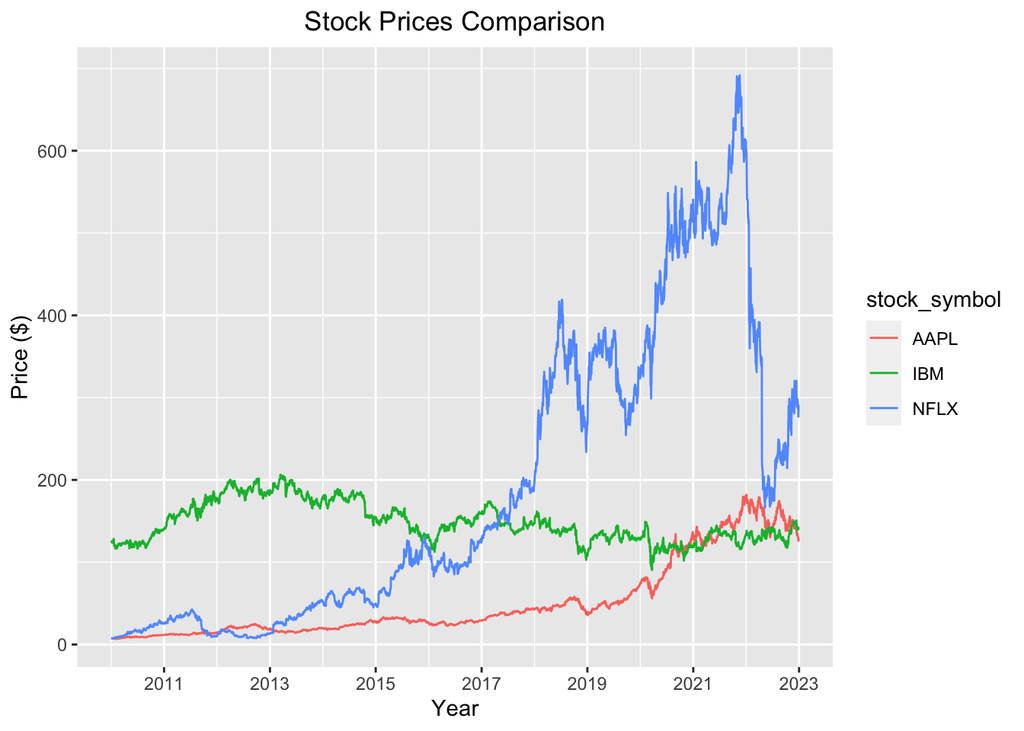

```r
AAPL_IBM_NFLX_2010_2023 <- big_tech_stock_prices |> filter(stock_symbol %in% c('AAPL', 'IBM', 'NFLX'))

ggplot(AAPL_IBM_NFLX_2010_2023,
       aes(x = date, y = close, color = stock_symbol)) +
       geom_line() +
       scale_x_date(date_breaks = '2 years', date_labels = '%Y') +  # Adjust this line for 2-year intervals
       labs(title = 'Stock Prices Comparison',
            x = 'Year',
            y = 'Price ($)') +
       theme(plot.title = element_text(hjust = 0.5))
```

The graph displays a comparison of stock prices for Apple (AAPL), IBM, and Netflix (NFLX) over a period ranging from before 2011 to beyond 2023. AAPL’s stock shows a significant upward trend with substantial growth. In contrast, IBM’s stock price appears relatively stable with less volatility, while NFLX shows a more volatile pattern with a steep increase until it peaks and then a sharp decline towards the end of the period.

2. Compare-analyze how Apple, Netflix, and IBM during COVID crisis.

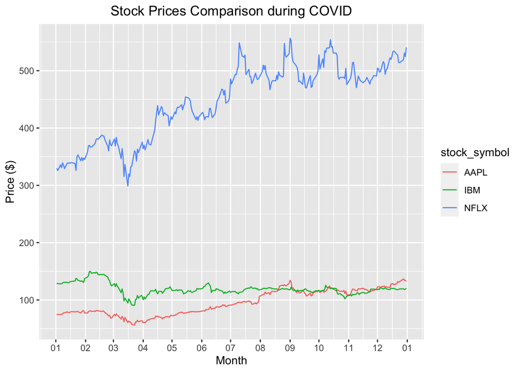

```r
AAPL_IBM_NFLX_covid <- AAPL_IBM_NFLX_2010_2023 |>
                           filter(date >= as.Date('2020-01-01') & date <= as.Date('2020-12-31'))

ggplot(AAPL_IBM_NFLX_covid,
       aes(x = date, y = close, color = stock_symbol)) +
       geom_line() +
       scale_x_date(date_breaks = '1 month', date_labels = '%m',) +  # Adjusted for month labels
       labs(title = 'Stock Prices Comparison during COVID',
            x = 'Month',
            y = 'Price ($)') +
       theme(plot.title = element_text(hjust = 0.5))
```

There is visible decline for all 3 companies in March-April 2020. Yet it is not as significant as I expected. Overall, Apple and Netflix grew, while IBM declined.

3. Establish which company performed best Jan 2014 to Jan 2022.

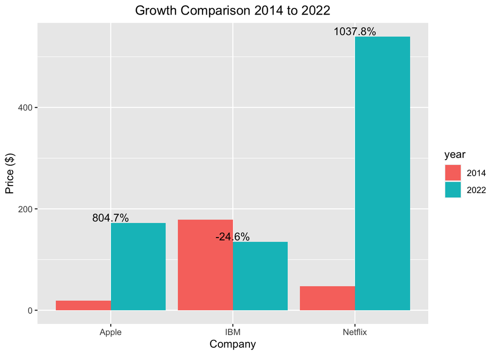

```r
companies <- c('Apple', 'IBM', 'Netflix')
prices_2014 <- AAPL_IBM_NFLX_2010_2023[AAPL_IBM_NFLX_2010_2023$date == as.Date('2014-01-10'), ]
prices_2022 <- AAPL_IBM_NFLX_2010_2023[AAPL_IBM_NFLX_2010_2023$date == as.Date('2022-01-10'), ]
percent_changes <- (prices_2022$close -
                   prices_2014$close) /
                   prices_2014$close * 100

prices_change <- data.frame(
  company = companies,
  price_2014 = prices_2014$close,
  price_2022 = prices_2022$close,
  percent_change = percent_changes
)

prices_change <- prices_change |> pivot_longer(
                                      cols = starts_with('price'),
                                      names_to = 'year',
                                      names_prefix = 'price_',
                                      values_to = 'price')

ggplot(prices_change, aes(x = company, y = price, fill = year)) +
  geom_bar(stat = 'identity', position = position_dodge()) +

  geom_text(data = subset(prices_change, year == '2022'),
            aes(label = sprintf("%.1f%%", percent_change)),
            position = position_dodge(width = 0.9), vjust = -0.2) +

  labs(title = 'Growth Comparison 2014 to 2022', x = 'Company', y = 'Price ($)') +
  theme(plot.title = element_text(hjust = 0.5))
```

The bar chart illustrates the growth comparison of stock prices between 2014 and 2022 for Apple, IBM, and Netflix. Apple’s stock price shows an 804.7% increase over the period, while Netflix’s stock price exhibits an even higher growth of 1037.8%. In contrast, IBM’s stock price experienced a decline, with a -24.6% change, indicating a decrease in stock value over the same timeframe.